# Exploring top players from NBA Basketball Datasets

Alina Karki ( u3219751)

## Introduction

The project focuses of anylysis of top players in each position of the basketball based on various metrics. Basketball is one of the popular games in the world which has five main positions such as Point Guard, Shooting Guard, Small Forward, Power Forward and Centre. The key parameters to indicate the player’salariescapability would depend on various factors such as how much points one scored, how many fouls he or she made, how many blocks, steals, rebound are there, how many goals were missed and so on.

In this project, in order to find the best player and recommend it to the client, Performance Index Rating (PER) of each player has been considered. As per the wikipedia (3), PER is the sum of negative measures of a player subtracted from sum of positive measures. i.e.,

$PER = (Points + Rebounds + Assists + Steals + Blocks)- (Missed Field Goals + Missed Free Throws + Turnovers + Fouls Committed)$ (3)

This project focus on caluculating PER of each player, finding predicted PER based on the above measures using linear regression to check if these parameters are good enough to calculate PER and finally finally recommeding best player in each position of basketball. Besides that, the project has also created various graphs (e.g. Distribution of Age, Salary etc.) in order to analyse overall dataset.

## Overview

The purposes of this document are following:

1. To analyse the various NBA datasets regarding players and team statistics
2. To tidy up and wrangle the datasets
3. To create various plots to analyse players performance relation with other variables

## Load Required Packages

```r
library(knitr)
library(tidyverse)
library(broom)
library(dplyr)
library(ggplot2)
library(scales)
```

## Data source

The data used in this documents are following:

1. 2018-19_nba_player-statistics.csv : sourced from [basketball-reference.com]
2. 2018-19_nba_player-salaries.csv : sourced from [hoopshype.com/salaries]
3. 2019-20_nba_team-payroll.csv : sourced from [hoopshype.com/salaries]
4. 2018-19_nba_team-statistics_1.csv : sourced from [basketball-reference.com]
5. 2018-19_nba_team-statistics_2.csv : sourced from [basketball-reference.com]

## Read Datasets

```r
# read in the data
# all datasets are stored in data directory
player_statistics <- read_csv("data/raw/2018-19_nba_player-statistics.csv")
player_salaries <- read.csv("data/raw/2018-19_nba_player-salaries.csv")

team_statistics_1 <- read_csv("data/raw/2018-19_nba_team-statistics_1.csv")
team_statistics_2 <- read_csv("data/raw/2018-19_nba_team-statistics_2.csv")

#team_statistic_2 has data that makes sense without missing values so lets take that data
team_statistics <- team_statistics_2
team_payroll <- read.csv("data/raw/2019-20_nba_team-payroll.csv")
```

## Checking the structure of datasets

Check the structure of the all the data files using `str()`:

```r
str(player_statistics)
```

```
## spec_tbl_df [708 × 29] (S3: spec_tbl_df/tbl_df/tbl/data.frame)
##  $ player_name: chr [1:708] "Alex Abrines" "Quincy Acy" "Jaylen Adams" "Steven Adams" ...
##  $ Pos        : chr [1:708] "SG" "PF" "PG" "C" ...
##  $ Age        : num [1:708] 25 28 22 25 21 21 25 33 21 23 ...
##  $ Tm         : chr [1:708] "OKC" "PHO" "ATL" "OKC" ...
##  $ G          : num [1:708] 31 10 34 80 82 19 7 81 10 38 ...
##  $ GS         : num [1:708] 2 0 1 80 28 3 0 81 1 2 ...
##  $ MP         : num [1:708] 588 123 428 2669 1913 ...
##  $ FG         : num [1:708] 56 4 38 481 280 11 3 684 13 67 ...
##  $ FGA        : num [1:708] 157 18 110 809 486 ...
##  $ FG%        : num [1:708] 0.357 0.222 0.345 0.595 0.576 0.306 0.3 0.519 0.333 0.376 ...
##  $ 3P         : num [1:708] 41 2 25 0 3 6 0 10 3 32 ...
##  $ 3PA        : num [1:708] 127 15 74 2 15 23 4 42 12 99 ...
##  $ 3P%        : num [1:708] 0.323 0.133 0.338 0 0.2 0.261 0 0.238 0.25 0.323 ...
##  $ 2P         : num [1:708] 15 2 13 481 277 5 3 674 10 35 ...
##  $ 2PA        : num [1:708] 30 3 36 807 471 ...
##  $ 2P%        : num [1:708] 0.5 0.667 0.361 0.596 0.588 0.385 0.5 0.528 0.37 0.443 ...
##  $ eFG%       : num [1:708] 0.487 0.278 0.459 0.595 0.579 0.389 0.3 0.522 0.372 0.466 ...
##  $ FT         : num [1:708] 12 7 7 146 166 4 1 349 8 45 ...
##  $ FTA        : num [1:708] 13 10 9 292 226 4 2 412 12 60 ...
##  $ FT%        : num [1:708] 0.923 0.7 0.778 0.5 0.735 1 0.5 0.847 0.667 0.75 ...
##  $ ORB        : num [1:708] 5 3 11 391 165 3 1 251 11 3 ...
##  $ DRB        : num [1:708] 43 22 49 369 432 16 3 493 15 20 ...
##  $ TRB        : num [1:708] 48 25 60 760 597 19 4 744 26 23 ...
##  $ AST        : num [1:708] 20 8 65 124 184 5 6 194 13 25 ...
##  $ STL        : num [1:708] 17 1 14 117 71 1 2 43 1 6 ...
##  $ BLK        : num [1:708] 6 4 5 76 65 4 0 107 0 6 ...
##  $ TOV        : num [1:708] 14 4 28 135 121 6 2 144 8 33 ...
##  $ PF         : num [1:708] 53 24 45 204 203 13 4 179 7 47 ...
##  $ PTS        : num [1:708] 165 17 108 1108 729 ...
##  - attr(*, "spec")=
##   .. cols(
##   ..   player_name = col_character(),
##   ..   Pos = col_character(),
##   ..   Age = col_double(),
##   ..   Tm = col_character(),
##   ..   G = col_double(),
##   ..   GS = col_double(),
##   ..   MP = col_double(),
##   ..   FG = col_double(),
```

[output cut: 8 more lines]

```
##   ..   `eFG%` = col_double(),
##   ..   FT = col_double(),
##   ..   FTA = col_double(),
##   ..   `FT%` = col_double(),
##   ..   ORB = col_double(),
##   ..   DRB = col_double(),
##   ..   TRB = col_double(),
##   ..   AST = col_double(),
##   ..   STL = col_double(),
##   ..   BLK = col_double(),
##   ..   TOV = col_double(),
##   ..   PF = col_double(),
##   ..   PTS = col_double()
##   .. )
##  - attr(*, "problems")=<externalptr>
```

```r
str(player_salaries)
```

```
## 'data.frame':    576 obs. of  3 variables:
##  $ player_id  : int  1 2 3 4 5 6 7 8 9 10 ...
##  $ player_name: chr  "Alex Abrines" "Quincy Acy" "Steven Adams" "Jaylen Adams" ...
##  $ salary     : int  3667645 213948 24157304 236854 2955840 77250 5285394 77250 2000000 22347015 ...
```

```r
str(team_statistics)
```

```
## spec_tbl_df [30 × 25] (S3: spec_tbl_df/tbl_df/tbl/data.frame)
##  $ Rk  : num [1:30] 1 2 3 4 5 6 7 8 9 10 ...
##  $ Team: chr [1:30] "Milwaukee Bucks" "Golden State Warriors" "New Orleans Pelicans" "Philadelphia 76ers" ...
##  $ G   : num [1:30] 82 82 82 82 82 82 82 82 82 82 ...
##  $ MP  : num [1:30] 19780 19805 19755 19805 19830 ...
##  $ FG  : num [1:30] 3555 3612 3581 3407 3384 ...
##  $ FGA : num [1:30] 7471 7361 7563 7233 7178 ...
##  $ FG% : num [1:30] 0.476 0.491 0.473 0.471 0.471 0.467 0.454 0.474 0.464 0.468 ...
##  $ 3P  : num [1:30] 1105 1087 842 889 821 ...
##  $ 3PA : num [1:30] 3134 2824 2449 2474 2118 ...
##  $ 3P% : num [1:30] 0.353 0.385 0.344 0.359 0.388 0.359 0.348 0.366 0.378 0.341 ...
##  $ 2P  : num [1:30] 2450 2525 2739 2518 2563 ...
##  $ 2PA : num [1:30] 4337 4537 5114 4759 5060 ...
##  $ 2P% : num [1:30] 0.565 0.557 0.536 0.529 0.507 0.523 0.51 0.539 0.504 0.543 ...
##  $ FT  : num [1:30] 1471 1339 1462 1742 1853 ...
##  $ FTA : num [1:30] 1904 1672 1921 2258 2340 ...
##  $ FT% : num [1:30] 0.773 0.801 0.761 0.771 0.792 0.814 0.713 0.804 0.726 0.768 ...
##  $ ORB : num [1:30] 762 797 909 892 796 ...
##  $ DRB : num [1:30] 3316 2990 2969 3025 2936 ...
##  $ TRB : num [1:30] 4078 3787 3878 3917 3732 ...
##  $ AST : num [1:30] 2136 2413 2216 2207 1970 ...
##  $ STL : num [1:30] 615 625 610 606 561 546 766 680 679 683 ...
##  $ BLK : num [1:30] 486 525 441 432 385 413 425 437 363 379 ...
##  $ TOV : num [1:30] 1137 1169 1215 1223 1193 ...
##  $ PF  : num [1:30] 1608 1757 1732 1745 1913 ...
##  $ PTS : num [1:30] 9686 9650 9466 9445 9442 ...
##  - attr(*, "spec")=
##   .. cols(
##   ..   Rk = col_double(),
##   ..   Team = col_character(),
##   ..   G = col_double(),
##   ..   MP = col_double(),
##   ..   FG = col_double(),
##   ..   FGA = col_double(),
##   ..   `FG%` = col_double(),
##   ..   `3P` = col_double(),
##   ..   `3PA` = col_double(),
##   ..   `3P%` = col_double(),
##   ..   `2P` = col_double(),
##   ..   `2PA` = col_double(),
##   ..   `2P%` = col_double(),
##   ..   FT = col_double(),
##   ..   FTA = col_double(),
##   ..   `FT%` = col_double(),
##   ..   ORB = col_double(),
##   ..   DRB = col_double(),
##   ..   TRB = col_double(),
##   ..   AST = col_double(),
##   ..   STL = col_double(),
##   ..   BLK = col_double(),
##   ..   TOV = col_double(),
##   ..   PF = col_double(),
##   ..   PTS = col_double()
##   .. )
##  - attr(*, "problems")=<externalptr>
```

```r
str(team_payroll)
```

```
## 'data.frame':    30 obs. of  3 variables:
##  $ team_id: int  1 2 3 4 5 6 7 8 9 10 ...
##  $ team   : chr  "Miami " "Golden State " "Oklahoma City " "Toronto " ...
##  $ salary : chr  "$153,171,497 " "$146,291,276 " "$144,916,427 " "$137,793,831 " ...
```

Check the first 6 rows of the data files using `head()`

```r
head(player_statistics)
```

```
## # A tibble: 6 × 29
##   player_name  Pos     Age Tm        G    GS    MP    FG   FGA `FG%`  `3P` `3PA`
##   <chr>        <chr> <dbl> <chr> <dbl> <dbl> <dbl> <dbl> <dbl> <dbl> <dbl> <dbl>
## 1 Alex Abrines SG       25 OKC      31     2   588    56   157 0.357    41   127
## 2 Quincy Acy   PF       28 PHO      10     0   123     4    18 0.222     2    15
## 3 Jaylen Adams PG       22 ATL      34     1   428    38   110 0.345    25    74
## 4 Steven Adams C        25 OKC      80    80  2669   481   809 0.595     0     2
## 5 Bam Adebayo  C        21 MIA      82    28  1913   280   486 0.576     3    15
## 6 Deng Adel    SF       21 CLE      19     3   194    11    36 0.306     6    23
## # … with 17 more variables: `3P%` <dbl>, `2P` <dbl>, `2PA` <dbl>, `2P%` <dbl>,
## #   `eFG%` <dbl>, FT <dbl>, FTA <dbl>, `FT%` <dbl>, ORB <dbl>, DRB <dbl>,
## #   TRB <dbl>, AST <dbl>, STL <dbl>, BLK <dbl>, TOV <dbl>, PF <dbl>, PTS <dbl>
```

```r
head(team_statistics)
```

```
## # A tibble: 6 × 25
##      Rk Team       G    MP    FG   FGA `FG%`  `3P` `3PA` `3P%`  `2P` `2PA` `2P%`
##   <dbl> <chr>  <dbl> <dbl> <dbl> <dbl> <dbl> <dbl> <dbl> <dbl> <dbl> <dbl> <dbl>
## 1     1 Milwa…    82 19780  3555  7471 0.476  1105  3134 0.353  2450  4337 0.565
## 2     2 Golde…    82 19805  3612  7361 0.491  1087  2824 0.385  2525  4537 0.557
## 3     3 New O…    82 19755  3581  7563 0.473   842  2449 0.344  2739  5114 0.536
## 4     4 Phila…    82 19805  3407  7233 0.471   889  2474 0.359  2518  4759 0.529
## 5     5 Los A…    82 19830  3384  7178 0.471   821  2118 0.388  2563  5060 0.507
## 6     6 Portl…    82 19855  3470  7427 0.467   904  2520 0.359  2566  4907 0.523
## # … with 12 more variables: FT <dbl>, FTA <dbl>, `FT%` <dbl>, ORB <dbl>,
## #   DRB <dbl>, TRB <dbl>, AST <dbl>, STL <dbl>, BLK <dbl>, TOV <dbl>, PF <dbl>,
## #   PTS <dbl>
```

```r
head(player_salaries)
```

```
##   player_id  player_name   salary
## 1         1 Alex Abrines  3667645
## 2         2   Quincy Acy   213948
## 3         3 Steven Adams 24157304
## 4         4 Jaylen Adams   236854
## 5         5  Bam Adebayo  2955840
## 6         6    Deng Adel    77250
```

```r
head(team_payroll)
```

```
##   team_id           team        salary
## 1       1         Miami  $153,171,497
## 2       2  Golden State  $146,291,276
## 3       3 Oklahoma City  $144,916,427
## 4       4       Toronto  $137,793,831
## 5       5     Milwaukee  $130,988,604
## 6       6      Portland  $130,256,600
```

Check the last 6 rows of the data files using `tail()`

```r
tail(player_statistics)
```

```
## # A tibble: 6 × 29
##   player_name Pos     Age Tm        G    GS    MP    FG   FGA `FG%`  `3P` `3PA`
##   <chr>       <chr> <dbl> <chr> <dbl> <dbl> <dbl> <dbl> <dbl> <dbl> <dbl> <dbl>
## 1 Ivica Zubac C        21 LAL      33    12   516   112   193 0.58      0     0
## 2 Ivica Zubac C        21 TOT      59    37  1040   212   379 0.559     0     0
## 3 Dario Saric PF       24 PHI      13    13   396    48   132 0.364    21    70
## 4 Dario Saric PF       24 MIN      68    28  1627   256   564 0.454    97   253
## 5 Dario Saric PF       24 TOT      81    41  2023   304   696 0.437   118   323
## 6 Ante Zizic  C        22 CLE      59    25  1082   183   331 0.553     0     0
## # … with 17 more variables: `3P%` <dbl>, `2P` <dbl>, `2PA` <dbl>, `2P%` <dbl>,
## #   `eFG%` <dbl>, FT <dbl>, FTA <dbl>, `FT%` <dbl>, ORB <dbl>, DRB <dbl>,
## #   TRB <dbl>, AST <dbl>, STL <dbl>, BLK <dbl>, TOV <dbl>, PF <dbl>, PTS <dbl>
```

```r
tail(player_salaries)
```

```
##     player_id  player_name   salary
## 571       571 Rade Zagorac  1378242
## 572       572  Cody Zeller 13528090
## 573       573 Tyler Zeller   213948
## 574       574   Ante Zizic  1952760
## 575       575  Ivica Zubac  1544951
## 576       576         Nene  3651480
```

```r
tail(team_statistics)
```

```
## # A tibble: 6 × 25
##      Rk Team       G    MP    FG   FGA `FG%`  `3P` `3PA` `3P%`  `2P` `2PA` `2P%`
##   <dbl> <chr>  <dbl> <dbl> <dbl> <dbl> <dbl> <dbl> <dbl> <dbl> <dbl> <dbl> <dbl>
## 1    25 Detro…    82 19855  3185  7238 0.44    993  2854 0.348  2192  4384 0.5
## 2    26 Miami…    82 19730  3251  7218 0.45    928  2658 0.349  2323  4560 0.509
## 3    27 Chica…    82 19905  3266  7205 0.453   745  2123 0.351  2521  5082 0.496
## 4    28 New Y…    82 19780  3134  7241 0.433   823  2421 0.34   2311  4820 0.479
## 5    29 Cleve…    82 19755  3189  7184 0.444   847  2388 0.355  2342  4796 0.488
## 6    30 Memph…    82 19880  3113  6924 0.45    811  2368 0.342  2302  4556 0.505
## # … with 12 more variables: FT <dbl>, FTA <dbl>, `FT%` <dbl>, ORB <dbl>,
## #   DRB <dbl>, TRB <dbl>, AST <dbl>, STL <dbl>, BLK <dbl>, TOV <dbl>, PF <dbl>,
## #   PTS <dbl>
```

```r
tail(team_payroll)
```

```
##    team_id        team        salary
## 25      25    Indiana  $110,724,804
## 26      26    Phoenix  $108,692,835
## 27      27  LA Lakers  $107,225,482
## 28      28 Sacramento  $101,466,920
## 29      29     Dallas   $86,958,881
## 30      30    Atlanta   $79,180,081
```

## Dealing with Missing Values

```r
sum(is.na(player_statistics)) # count the missing values
```

```
## [1] 117
```

```r
head(which(is.na(player_statistics), arr.ind = TRUE)) # find where the missing values are (showing only first 6 rows)
```

```
##      row col
## [1,] 303  10
## [2,] 371  10
## [3,] 478  10
## [4,] 600  10
## [5,] 614  10
## [6,] 652  10
```

## Plotting missing values for player statistics

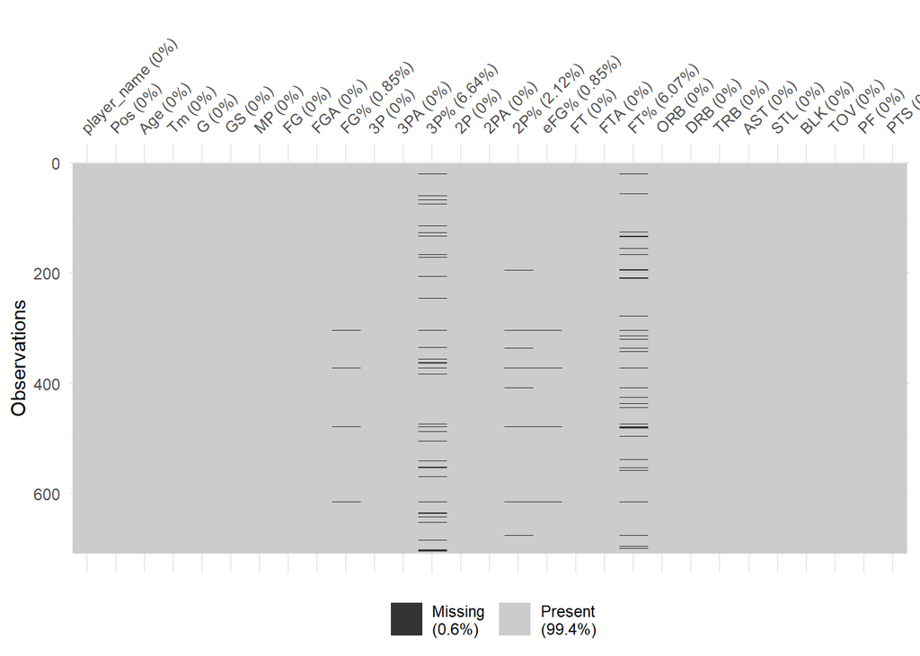

Plot of missing values

```r
naniar::vis_miss(player_statistics)
```

```r
sum(is.na(player_salaries))
```

```
## [1] 0
```

```r
sum(is.na(team_statistics))
```

```
## [1] 0
```

```r
sum(is.na(team_payroll))
```

```
## [1] 0
```

```r
player_statistics <- drop_na(player_statistics)
team_statistics <- drop_na(team_statistics)
sum(is.na(player_statistics)) # check for missing values again
```

```
## [1] 0
```

```r
sum(is.na(team_statistics))
```

```
## [1] 0
```

As per the data structure and our research scope, only two datasets ( player_statistics and player_salaries) out of four are decided to be used.

Now player_name field has some duplicate values so lets check for duplicate player name and use only distinct players . Also, lets merge the player statistics and salary dataframe.

```r
player_statistics <- distinct(player_statistics,player_name,.keep_all = TRUE)

# combine player statistics and salary
player_statistics <- merge(player_statistics, player_salaries, by.x = "player_name", by.y = "player_name")
```

## Exploratory Analysis

Now that we have our dataset ready, lets randomly discover different plots just to get the general ideas.

### Analysis of distribution of age

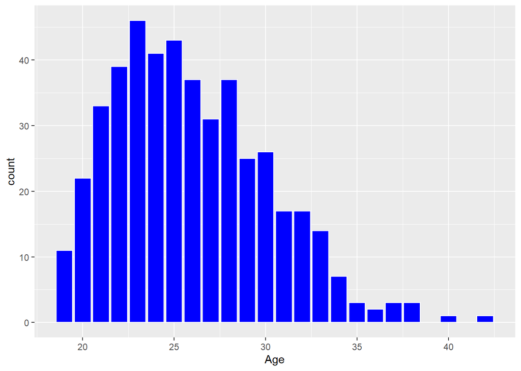

```r
player_statistics %>%
  ggplot(aes(x=Age))+
  geom_bar(color="white", fill="blue")
```

### Analysis of salary of players based on points

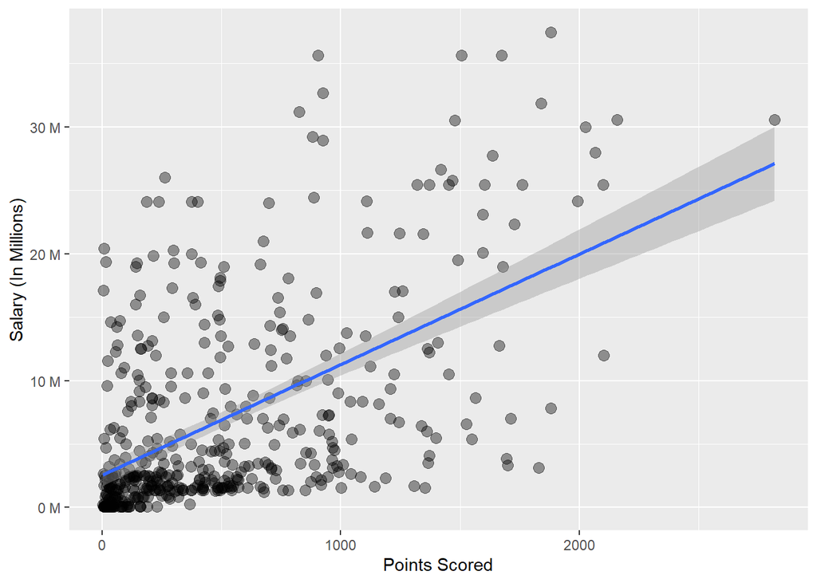

```r
ggplot(player_statistics,
  aes(x = PTS, y = salary)) +
  geom_point(alpha = .4, size = 3) +
  xlab("Points Scored")+
  ylab("Salary (In Millions)")+
  scale_y_continuous(labels = label_number(suffix = " M", scale = 1e-6))+ # millions
  geom_smooth(method = "lm")
```

Now, lets just play with the data to view top players and their salaries and plot them.

```r
top_10_salary <- player_statistics %>%
  arrange(desc(salary)) %>%
  top_n(10)
```

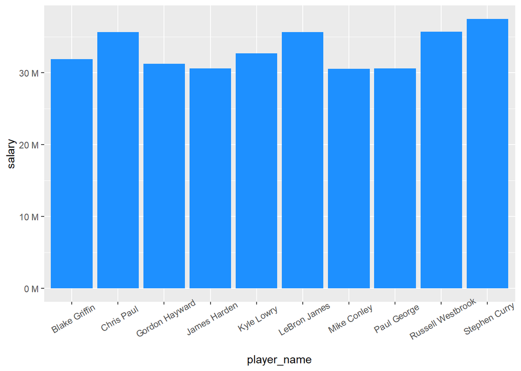

```r
ggplot(data = top_10_salary)+
  geom_bar(mapping = aes(x = player_name, y=salary), fill = "dodgerblue", stat = "identity")+
  scale_y_continuous(labels = label_number(suffix = " M", scale = 1e-6))+ # millions
  theme(axis.text.x = element_text(angle = 30, vjust = 0.8))
```

We have to determine PER of each player so that we can find best player using various metrics. Now, lets create new column PER based on the formula

```r
player_statistics <- player_statistics %>%
  mutate(PER = (PTS+TRB+AST+STL+BLK)-(FGA+FTA+TOV+PF))
```

We can now consider PER as our predictive variable so lets compare PER with other response variables.

Also, we can consider this dataset as final and processed so lets save this dataset into respective processed folder.

```r
write.csv(player_statistics,'data/processed/player_statistics.csv')
```

## Distribution or PER

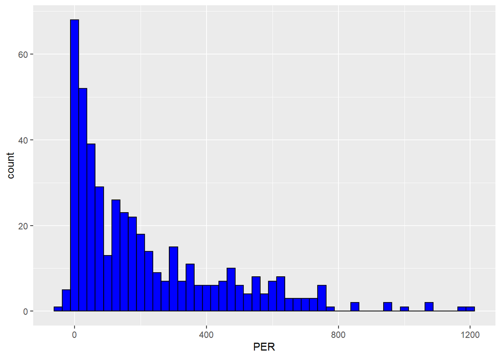

```r
ggplot(data = player_statistics, aes(x = PER)) +
  geom_histogram(binwidth = 25, colour = "black", fill = "blue")
```

```r
# the distribution is right skewed
```

Also, lets check the relationship of PER with different variables we used in equations. # PTS vs PER

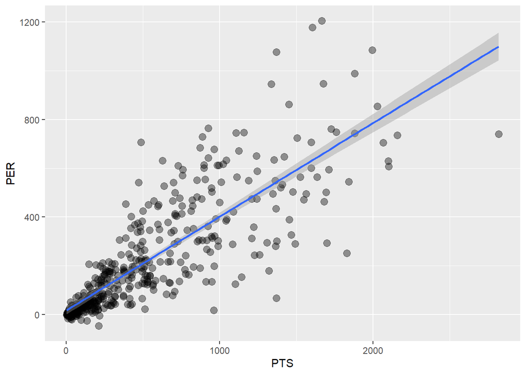

```r
ggplot(player_statistics, aes(x = PTS, y = PER)) +
  geom_point(alpha = .4, size = 3) +
  geom_smooth(method = "lm")
```

```r
# moderate linear relation
```

### Salary vs PER

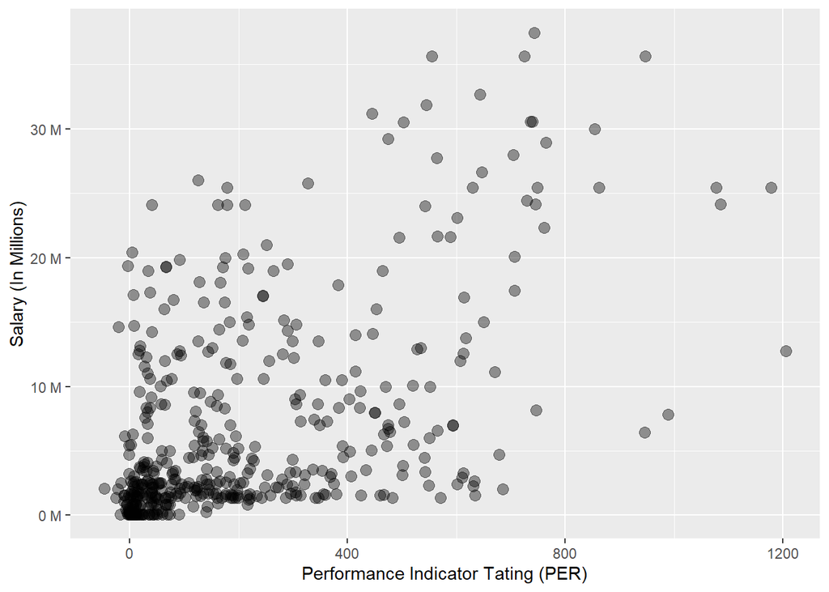

```r
ggplot(player_statistics,
  aes(x = PER, y = salary)) +
  geom_point(alpha = .4, size = 3) +
  xlab("Performance Indicator Tating (PER)")+
  ylab("Salary (In Millions)")+
  scale_y_continuous(labels = label_number(suffix = " M", scale = 1e-6)) # millions
```

### Age vs Salary

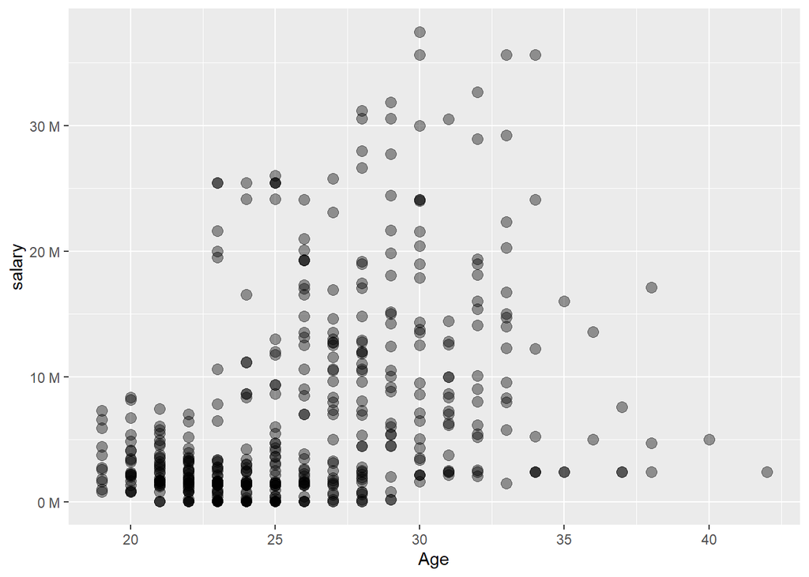

```r
ggplot(player_statistics,
       aes(x = Age, y = salary)) +
  geom_point(alpha = .4, size = 3) +
  scale_y_continuous(labels = label_number(suffix = " M", scale = 1e-6)) # millions
```

```r
# no clear relation
```

## Linear Regression

Now lets use multiple linear regression to evaluate our basketball success matrix with the PER of the player.

```r
fit <- lm(PER ~ PTS+TRB+AST+STL+BLK, player_statistics)
tidy(fit, conf.int = TRUE)
```

```
## # A tibble: 6 × 7
##   term        estimate std.error statistic  p.value conf.low conf.high
##   <chr>          <dbl>     <dbl>     <dbl>    <dbl>    <dbl>     <dbl>
## 1 (Intercept) -30.1       4.33       -6.95 1.31e-11 -38.6    -21.6
## 2 PTS          -0.0294    0.0127     -2.31 2.13e- 2  -0.0544  -0.00440
## 3 TRB           0.777     0.0330     23.6  8.77e-81   0.712    0.842
## 4 AST           0.638     0.0427     14.9  3.23e-41   0.554    0.722
## 5 STL           0.254     0.180       1.42 1.57e- 1  -0.0984   0.607
## 6 BLK           0.899     0.174       5.18 3.38e- 7   0.558    1.24
```

Lets check the multicollinearity by following code.

```r
car::vif(fit)
```

```
##      PTS      TRB      AST      STL      BLK
## 4.946092 5.064740 3.947667 4.111716 2.872128
```

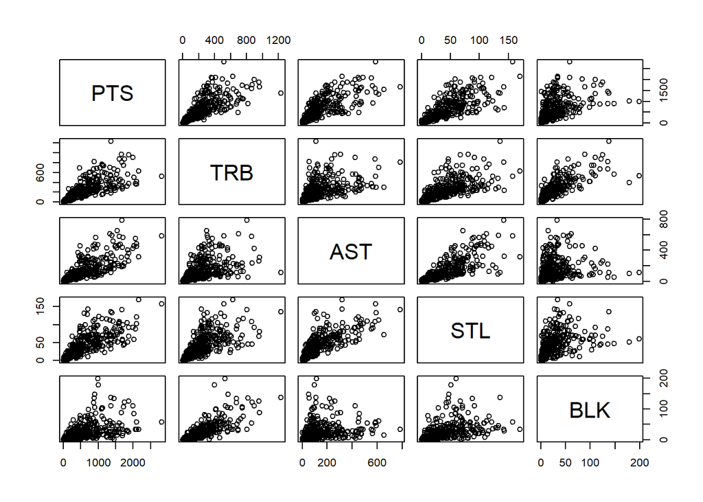

```r
pairs(formula = ~ PTS+TRB+AST+STL+BLK, data = player_statistics)
```

```r
# we can see that some values have almost same distance and patters indicating multicollinearlity
```

# Plot of regression

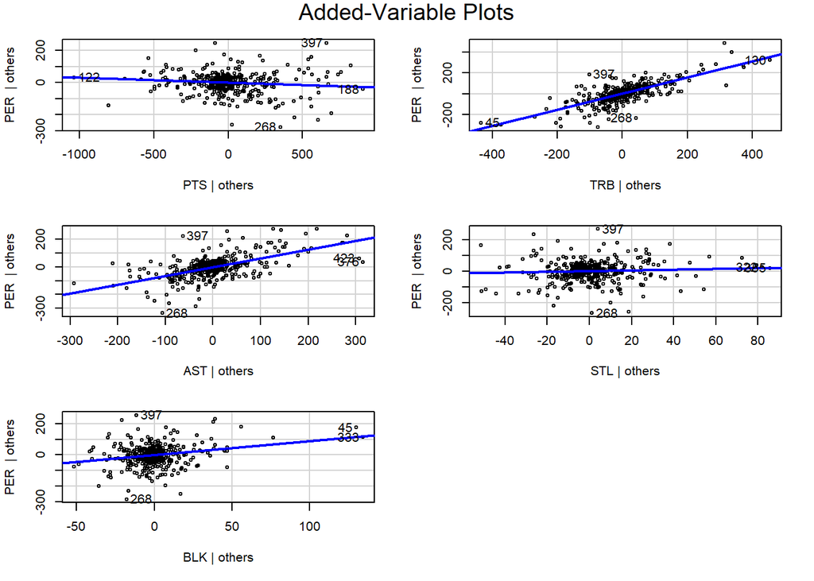

```r
car::avPlots(fit)
```

## Testing Heteroscedasticity

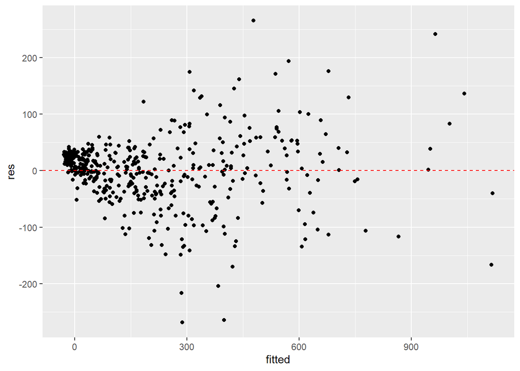

```r
res <- residuals(fit)
fitted <- predict(fit)

ggplot(data = NULL, aes(x = fitted, y = res)) +
  geom_point(colour = "black") +
  geom_hline(yintercept = 0, colour = "red", linetype = "dashed")
```

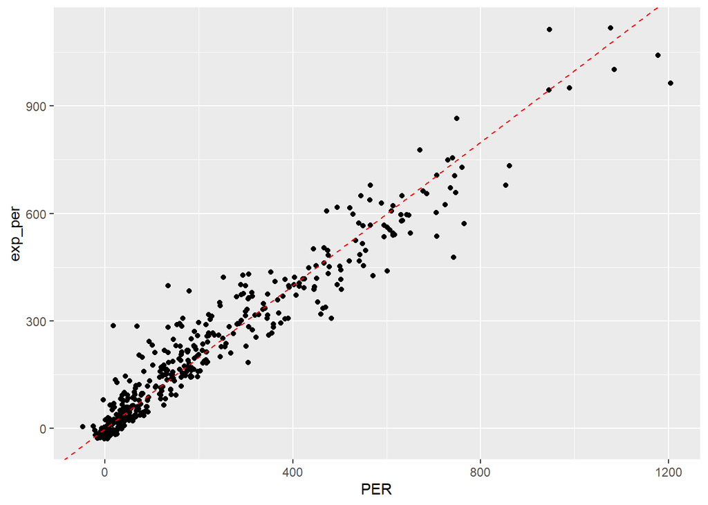

```r
new_df <- mutate(player_statistics, exp_per=predict(fit, newdata = player_statistics))

# plot data
ggplot(data = new_df, aes(x = PER, y = exp_per)) +
  geom_point(colour = "black") +
  geom_abline(colour = "red", linetype = "dashed")
```

We can see the clear linear relationship among the calculated PER and predicted PER indicating our model as accurate enough. Thus, based on the PER we can choose our top players. To check top player in each position based on PER, we can use following section of code.

## Player Recommendation

Based on above linear models and the formula, the players recommended would be the one with highest PER. Following block of code presents the top player based on PER in each of the position in basketball.

```r
top_5_player <- player_statistics %>%
  group_by(Pos) %>%
  arrange(desc(PER)) %>%
  select(Pos,player_name,Age,PER, salary) %>%
  filter(row_number()==1)

print(top_5_player)
```

```
## # A tibble: 5 × 5
## # Groups:   Pos [5]
##   Pos   player_name             Age   PER   salary
##   <chr> <chr>                 <dbl> <dbl>    <int>
## 1 C     Nikola Vucevic           28  1205 12750000
## 2 PF    Giannis Antetokounmpo    24  1085 24157304
## 3 PG    Russell Westbrook        30   947 35665000
## 4 SF    Kevin Durant             30   854 30000000
## 5 SG    Jrue Holiday             28   647 26641111
```

## Limitations

1. Due to lack of proper knowledge in basketball, overall project is solely based on whatever knowledge could be gained online.
2. The accuracy of the predicted results hasnot been guranteed.

## References

1. NBA Salary Prediction using Multiple Regression [Internet]. Kaggle.com. 2022 [cited 6 May 2022]. Available from: https://www.kaggle.com/code/koki25ando/nba-salary-prediction-using-multiple-regression
2. NBA Analytics Tutorial: Using R to Display Player Career Stats | R-bloggers [Internet]. R-bloggers. 2022 [cited 6 May 2022]. Available from: https://www.r-bloggers.com/2021/12/nba-analytics-tutorial-using-r-to-display-player-career-stats/
3. Efficiency (basketball) - Wikipedia [Internet]. En.wikipedia.org. 2022 [cited 6 May 2022]. Available from: https://en.wikipedia.org/wiki/Efficiency_(basketball)